# Machine Learning_Fernanda Jube

FJube

10/05/2020

## Introduction

The aim of this project is to take the data regarding accelerometers on the belt, forearm, arm, and dumbell taken from quantifying self movement devices of 6 participants and predict the manner in which they did the exercise. The first step is to train the data taking the training data using different algorithims. After that a predition will be realized and the model that has the highest accuracy will be selected.

## Loading the data

```r
library(caret)
training<-read.csv('pml-training.csv')
testing<-read.csv('pml-testing.csv')
head(training)
```

```
##   X user_name raw_timestamp_part_1 raw_timestamp_part_2   cvtd_timestamp
## 1 1  carlitos           1323084231               788290 05/12/2011 11:23
## 2 2  carlitos           1323084231               808298 05/12/2011 11:23
## 3 3  carlitos           1323084231               820366 05/12/2011 11:23
## 4 4  carlitos           1323084232               120339 05/12/2011 11:23
## 5 5  carlitos           1323084232               196328 05/12/2011 11:23
## 6 6  carlitos           1323084232               304277 05/12/2011 11:23
##   new_window num_window roll_belt pitch_belt yaw_belt total_accel_belt
## 1         no         11      1.41       8.07    -94.4                3
## 2         no         11      1.41       8.07    -94.4                3
## 3         no         11      1.42       8.07    -94.4                3
## 4         no         12      1.48       8.05    -94.4                3
## 5         no         12      1.48       8.07    -94.4                3
## 6         no         12      1.45       8.06    -94.4                3
##   kurtosis_roll_belt kurtosis_picth_belt kurtosis_yaw_belt skewness_roll_belt
```

[output cut: 251 more lines]

## Pre-processing the data

As we could observe in the training data frame, there are some strings as “#DIV/0!” that must be eliminated. So the reloaded data is done as follows:

```r
training<-read.csv('pml-training.csv' , na.strings=c("#DIV/0!","NA"))
testing<-read.csv('pml-testing.csv', na.strings=c("#DIV/0!","NA"))
dim(training)
```

```
## [1] 19622   160
```

```r
dim(testing)
```

```
## [1]  20 160
```

```r
training[1:7]<-NULL
testing[1:7]<-NULL
training<-training[,colSums(is.na(training)) == 0]
testing <-testing[,colSums(is.na(testing)) == 0]
dim(training)
```

```
## [1] 19622    53
```

```r
dim(testing)
```

```
## [1] 20 53
```

## Parting data

```r
set.seed(3422)
datapart<-createDataPartition(training$classe,p=3/4)[[1]]
tr1 = training[datapart, ]
test1 = training[-datapart, ]
```

## Training data

The algorithims choosen to train the data are random forest and decision tree which are the most indicated to predict categorical variables.

### Random Forest

```r
library(randomForest)
set.seed(34511)
mode_rf<-randomForest(classe~.,data=tr1)
pred_rf<-predict(mode_rf,test1)
confusionMatrix(pred_rf, test1$classe)
```

```
## Confusion Matrix and Statistics
##
##           Reference
## Prediction    A    B    C    D    E
##          A 1395    7    0    0    0
##          B    0  942    1    0    0
##          C    0    0  853   13    0
##          D    0    0    1  791    1
##          E    0    0    0    0  900
##
## Overall Statistics
##
##                Accuracy : 0.9953
##                  95% CI : (0.993, 0.997)
##     No Information Rate : 0.2845
##     P-Value [Acc > NIR] : < 2.2e-16
##
##                   Kappa : 0.9941
##
##  Mcnemar's Test P-Value : NA
##
## Statistics by Class:
##
##                      Class: A Class: B Class: C Class: D Class: E
## Sensitivity            1.0000   0.9926   0.9977   0.9838   0.9989
## Specificity            0.9980   0.9997   0.9968   0.9995   1.0000
## Pos Pred Value         0.9950   0.9989   0.9850   0.9975   1.0000
## Neg Pred Value         1.0000   0.9982   0.9995   0.9968   0.9998
## Prevalence             0.2845   0.1935   0.1743   0.1639   0.1837
## Detection Rate         0.2845   0.1921   0.1739   0.1613   0.1835
## Detection Prevalence   0.2859   0.1923   0.1766   0.1617   0.1835
## Balanced Accuracy      0.9990   0.9962   0.9972   0.9917   0.9994
```

### Decision Tree

```r
library(rpart)
set.seed(34511)
mode_dt<-rpart(classe ~ ., data=tr1, method="class")
pred_dt<-predict(mode_dt, test1, type = "class")
confusionMatrix(pred_dt, test1$classe)
```

```
## Confusion Matrix and Statistics
##
##           Reference
## Prediction    A    B    C    D    E
##          A 1288  192   17   90   39
##          B   34  561   80   34   76
##          C   36   88  687  134  101
##          D   18   56   46  495   47
##          E   19   52   25   51  638
##
## Overall Statistics
##
##                Accuracy : 0.7482
##                  95% CI : (0.7358, 0.7603)
##     No Information Rate : 0.2845
##     P-Value [Acc > NIR] : < 2.2e-16
##
##                   Kappa : 0.6796
##
##  Mcnemar's Test P-Value : < 2.2e-16
##
## Statistics by Class:
##
##                      Class: A Class: B Class: C Class: D Class: E
## Sensitivity            0.9233   0.5911   0.8035   0.6157   0.7081
## Specificity            0.9037   0.9434   0.9113   0.9593   0.9633
## Pos Pred Value         0.7921   0.7146   0.6568   0.7477   0.8127
## Neg Pred Value         0.9674   0.9058   0.9565   0.9272   0.9361
## Prevalence             0.2845   0.1935   0.1743   0.1639   0.1837
## Detection Rate         0.2626   0.1144   0.1401   0.1009   0.1301
## Detection Prevalence   0.3316   0.1601   0.2133   0.1350   0.1601
## Balanced Accuracy      0.9135   0.7673   0.8574   0.7875   0.8357
```

```r
mode_dt$finalModel
```

[output not shown]

```r
library(rattle)
```

```r
fancyRpartPlot(mode_dt)
```

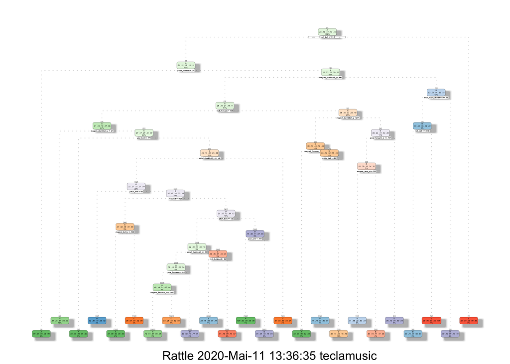

[figure not shown]

### Conclusion

That been concluded, the random forest is the model more adequated to predict with this data.

### Quiz

```r
quiz<-predict(mode_rf,testing,type="class")
quiz
```

```
##  1  2  3  4  5  6  7  8  9 10 11 12 13 14 15 16 17 18 19 20
##  B  A  B  A  A  E  D  B  A  A  B  C  B  A  E  E  A  B  B  B
## Levels: A B C D E
```

### Bibliographic References

VELLOSO, E.; BULLING, A.; GELLERSEN, H.; UGULINO, W.; FUKS, H. Qualitative Activity Recognition of Weight Lifting Exercises. Proceedings of 4th International Conference in Cooperation with SIGCHI (Augmented Human ’13) . Stuttgart, Germany: ACM SIGCHI, 2013.